# R Notebook

This assignment is about analyzing words and their frequencies in text documents for NLP (natural language processing). The numerical statistic frequency-inverse document frequency,tf-idf, is used to determine how important a word is in a collection of documents. This decreases weights of words that are often used in a collection and increases the weights of words less often used in that collection of documents.

The collection of documents chosen for this script was classic children’s books written in the 19th century by English authors.

Books and Authors: Alice’s Adventures in Wonderland by Lewis Carroll The Jungle Book by Rudyard Kipling A Christmas Carol in Prose; Being a Ghost Story of Christmas by Charles Dickens The Princess and the Goblin by George MacDonald The King of the Golden River; or, the Black Brothers: A Legend of Stiria. by John Ruskin

Let’s start

install all the necessary packages and libraries

```r
library(gutenbergr)
library(tidyverse)
library(wordcloud)
```

The words we would like to investigate are first extracted from Project Gutengurg which is a free e-books project.

```r
children_novels <- gutenberg_download(c(11, 35997, 46, 34339, 33673), meta_fields = "title") %>% select(text, title)
```

We now have all the books downloaded with text and book titles. Now we need to manipulate this data so each word is it’s own row. We will now turn it into a tidy text dataset

```r
tidy_novels <- children_novels %>%
  unnest_tokens(word, text)
```

Each word is it’s own row now so now we can count the words and group them by their book title.

```r
word_count <- count(tidy_novels, title, word, sort = TRUE)
```

When we look at the count we see an extremely of rudimentary words that don’t have significant meaning in the context of these classic children novels. Words such as “the”, “and”, “to”, “of”, etc. Therefor, we use the tf_idf statistic to weight the words in our collection of children books so we can see beyond the rudimentary words.

```r
weighted_words <- word_count %>%
  bind_tf_idf(word, title, n) %>%
  arrange(desc(tf_idf))
```

Our words are now weighted according to their importance in our children book’s collection. As you can see words such as “Scrooge”, “jungle”, “thirst”, and others have become important. Let’s plot these new findings to get a better understanding.

Before we plot it we need to change the words and titles into factors because we will re-order the words and this way we will also keep the order of our graphs in accordance with the book titles. We also had to use unique when factoring the words because there are duplicates.

```r
plot_prep <- weighted_words %>%
  mutate(word = factor(word, levels = unique(word))) %>%
  mutate(title = factor(title, levels = c("Alice's Adventures in Wonderland", "The Jungle Book","A Christmas Carol in Prose; Being a Ghost Story of Christmas", "The Princess and the Goblin", "The King of the Golden River; or, the Black Brothers: A Legend of Stiria.")))
```

Now we can plot.

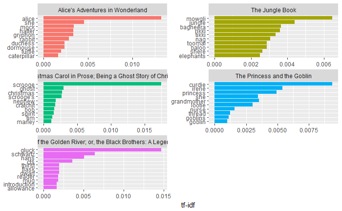

```r
plot_prep %>%
  group_by(title) %>%
  top_n(10, tf_idf) %>%
  ungroup() %>%
  mutate(word = reorder(word, tf_idf)) %>%
  ggplot(aes(word, tf_idf, fill = title)) +
  geom_col(show.legend = FALSE) +
  labs(x = NULL, y = "tf-idf") +
  facet_wrap(~title, ncol =2, scales = "free") +
  coord_flip()
```

However, the word “she” seems to still be there even though it is somewhat redundant. Let’s go ahead and remove it.

```r
remove_words <- data_frame(word = "she")  # you would make a vector with c("remove_word1", "remove_word2")
tidy_novels_removed_word <- anti_join(tidy_novels, remove_words, by = "word")
```

Lets re-plot and see how it looks

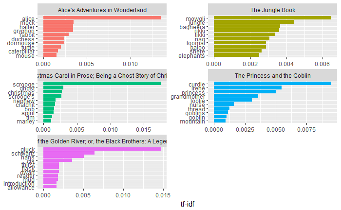

```r
tidy_novels_removed_word %>%
  count(title, word, sort = TRUE) %>%
  bind_tf_idf(word, title, n) %>%
  arrange(desc(tf_idf)) %>%
  mutate(word = factor(word, levels = unique(word))) %>%
  mutate(title = factor(title, levels = c("Alice's Adventures in Wonderland", "The Jungle Book","A Christmas Carol in Prose; Being a Ghost Story of Christmas", "The Princess and the Goblin", "The King of the Golden River; or, the Black Brothers: A Legend of Stiria.")))%>%
  group_by(title) %>%
  top_n(10, tf_idf) %>%
  ungroup() %>%
  mutate(word = reorder(word, tf_idf)) %>%
  ggplot(aes(word, tf_idf, fill = title)) +
  geom_col(show.legend = FALSE) +
  labs(x = NULL, y = "tf-idf") +
  facet_wrap(~title, ncol =2, scales = "free") +
  coord_flip()
```

In conclusion, we can see the most important words in a particular childrens book in a collection of children books. As it is evident, the rudimentary words such as “the”, “and”, “to”, etc. no longer have significance of importance. This is one aspect of how we can inspect text data for NLP.

Just for fun, let’s have fun with visuals and make a wordcloud of the MOST redundant words we found in the all of the childrens books. Do these words look familiar regardless of what document they come from?

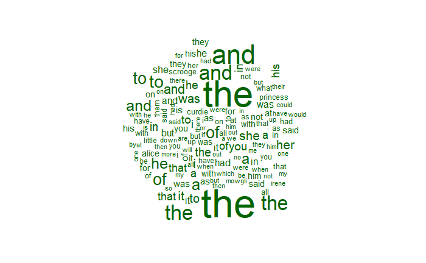

```r
weighted_words %>%
  with(wordcloud(word, n, colors="dark green",max.words = 150))
```